# ARIMA

73-423 Forecasting for Economics and Business

## Outline

- Moving Average Probability Model
  - Properties
  - Relation to Autoregression
- Extensions
  - ARIMA model
  - Seasonal ARIMA Model
- Multivariate Models
- Application: Macro Forecasting

## Probability Models and Hidden Variables

- With additive and autoregressive models, series is sum of many fixed components and one residual or error term
  - $y_t=s(t)+h(t)+g(t)+\sum_{j=1}^{p}b_jy_{t-p}+\epsilon_t$
- Given past data $\mathcal{Y}_{t-1}$, all randomness in predicted distribution comes from $\epsilon_t$
- This is convenient for producing a predictor and writing down a likelihood
  - If $\epsilon_t\sim f(x)$, conditional likelihood of observation $t$ is $\ell(y_t|\mathcal{Y}_{t-1})=f(y_t-s(t)-h(t)-g(t)-\sum_{j=1}^{p}b_jy_{t-p})$
- Interpretation is that all predictive information is encoded in additive terms
- In principle, there can be *multiple* sources of variation in $y_t$ which are not seen
  - “Hidden”, or **latent** variables, which may evolve over time, may affect $y_t$
- For forecasting, we don’t care about the hidden variables themselves: don’t need to figure out what they are
  - But they can create detectable patterns in the series we do care about
- Allowing for hidden variables can allow simple way to account for these patterns
  - But also create challenges due to indirect and complicated relationship between model and predictor
- The **Moving Average** (MA) Model is one of the most popular and useful hidden variables models

## The Moving Average Model: Origin

- Russian economist Eugen Slutsky investigated how regular economic patterns could arise from pure randomness
  - He took a long string of random numbers from the lottery, and took the average of the first 10
  - Then he shifted the window over by 1, taking an average of the 2nd through 11th numbers
  - He repeated this through the full string, producing a sequence of overlapping averages, a **moving average**
- In this process, he produced a sequence that looked remarkably like the fluctuations observed in economic series
- He theorized that such a mechanism, where sequences of purely random shocks are combined to produce a single number, might describe the origins of economic cycles
- Today, *moving average* refers to a process generated by overlapping weighted combinations of random variables

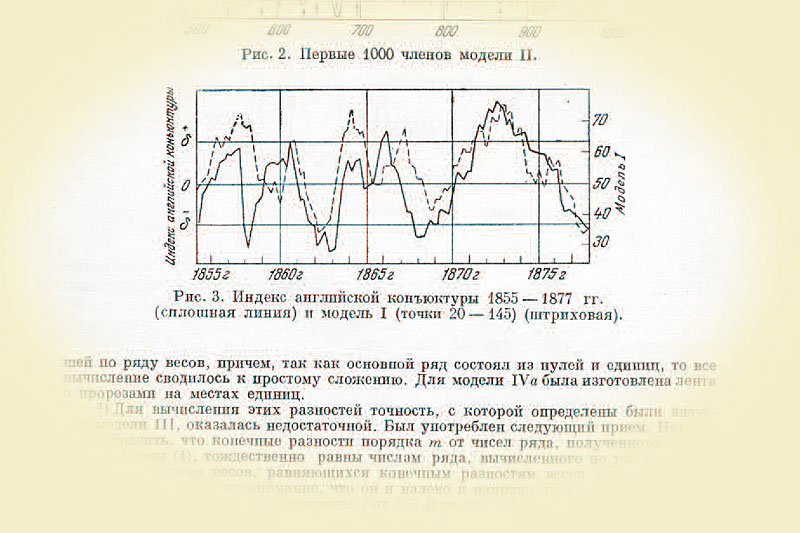

Slutsky’s Moving Average (cf Mahon & Davies 2009)

## The Moving Average Model

- Consider a sequence of mean 0 uncorrelated **shocks** $e_t$ $t=1\ldots T$ which are *not* observed
  - $E[e_t]=0$, $E[e_te_{t-h}]=0$ for all t, for all $h\neq0$
- The observed data is still $\{y_t\}_{t=1}^T$
- The **Moving Average** Model (of order q) says that $y_t$ is a weighted sum of present and past shocks
  - For all $t$, $y_t=e_t+\sum_{j=1}^{q}\theta_{j}e_{t-j}$
- Coefficients $\theta=\{\theta_j\}_{j=1}^{q}$ determine relationship between observations over time
- In lag polynomial notation, let $\theta(L)=1+\sum_{j=1}^{q}\theta_jL^j$, then $y_t=\theta(L)e_t$
- To produce a full likelihood, strengthen assumption to $e_t\overset{iid}{\sim}f()$, usually $N(0,\sigma_e^2)$
- Compare to the **Autoregression** model: $y_t$ is a weighted sum of a present shock and past *observations*
  - For all $t$, $y_t=e_t+\sum_{j=1}^{q}b_{j}y_{t-j}$
  - Lag polynomial representation $b(L)y_t=e_t$ has lags on the left side instead of the right

## Properties

- The appeal of the MA model comes from the fact that although $e_t$ never directly seen, the properties of the data are characterized explicitly by the model
- In particular, the Autocovariance function is determined by parameters $\theta$
- $\gamma(h):=Cov(y_{t},y_{t-h})=Cov(e_t+\sum_{j=1}^{q}\theta_{j}e_{t-j},e_{t-h}+\sum_{j=1}^{q}\theta_{j}e_{t-j-h})$ $=\sigma_e^2\sum_{j=0}^{q}\sum_{k=0}^q\theta_{j}\theta_{k}\delta_{k=h+j}$
  - In words, covariances are determined by the moving average components shared between times
- Consider, e.g. MA(1), $y_t=e_t+\theta_1e_{t-1}$
  - $\gamma(0)=Var(y_t)=\sigma_e^2(1+\theta_1^2)$, $\gamma(1)=Cov(y_t,y_{t-1})=\sigma_e^2\theta_1$, $\gamma(j)=0$, for all $j\geq 2$
- Last property, that autocovariance function drops to 0 at $q+1$, is true for any $MA(q)$
  - Beyond the window of length q, the moving averages do not overlap, and observations are uncorrelated
- MA(q) model allows modeling short term correlations up to length $q$ horizon: predicted mean goes to 0 in finite time
- By allowing long enough $q$, can, with many coefficients, describe very general patterns of relationships
- As an MA model is linear, like AR model, does not allow for general patterns of higher-order properties like conditional variance, skewness etc

## Challenge: Identifiability

- Difficulty of models with latent variables is that one cannot learn about the $e_t$ directly, but only their properties
- With two or more random components determining one observation, might not be able to distinguish which one was the source of any change
  - This is called an **identification** problem in econometrics
- Consider MA(1) processes $y_t=e_t+\frac{1}{2}e_{t-1}$, $e_t\overset{iid}{\sim}N(0,\sigma_{e}^2)$ and $y_t=u_t+2u_{t-1}$, $u_t\overset{iid}{\sim}N(0,\frac{\sigma_{e}^2}{4})$
- We see ACF of first is $\gamma(0)=\frac{5}{4}\sigma_e^2$, $\gamma(1)=\frac{\sigma_e^2}{2}$
  - ACF of second process is exactly the same, so by normality, distribution is also exactly the same
- This is an example of a general phenomenon: factorizing $\theta(L)=\Pi_{j=1}^{q}(1+t_jL)$ with inverse roots $t_j$, there is an equivalent representation $\tilde{\theta}(L)=\Pi_{j=1}^{q}(1+\frac{1}{t_j}L^j)$ with flipped roots and a different $\sigma^2_e$
- Does this make a difference? Not for forecasting: properties of series the same either way
  - Can simply restrict interest to a representation with all roots inside the unit circle, for Bayesian or statistical approach
- General lesson is that when building model out of unobserved parts, might not be able to learn all about them

## Relationship to Autoregression Model

- Properties of MA model can be seen by repeated substitution
  - Consider MA(1) $y_t=e_t+\theta_1e_{t-1}$ rearrange as $e_t=y_{t}-\theta_1e_{t-1}$
- Can substitute in past values $e_{t-1}$ into this formula repeatedly
  - $e_t=y_{t}-\theta_1(y_{t-1}-\theta_1e_{t-2})=y_{t}-\theta_1y_{t-1}+\theta^2_1e_{t-2}$
  - $=y_{t}-\theta_1y_{t-1}+\theta^2_1(y_{t-2}-\theta_1e_{t-3})=y_{t}-\theta_1y_{t-1}+\theta^2_1y_{t-2}-\theta^3_1e_{t-3}=\ldots$
- Continuing indefinitely, have, in lag polynomial notation, $(1-\sum_{j=1}^{\infty}(-\theta_1)^jL^j)y_t=e_t$
  - This is exactly an (infinite order) autoregression model
- This equivalence holds in general: a finite order MA model is an infinite order AR model
- Intuition: because $e_t$ never seen exactly, must use all past information in $\mathcal{Y}_t$ to predict it
- Observable implication: PACF will decay to 0 smoothly, rather than dropping off like AR
- Equivalence also holds in reverse: a finite order AR model is an infinite order MA model
  - Repeatedly substituting, AR(1) $y_t=b_1y_{t-1}+e_t$ becomes $y_t=e_t+\sum_{j=1}^{\infty}b^j_1e_{t-j}$
- Can use either, but one representation may be much less complex

## Estimation

- Because the shocks are not observed, likelihood formula for MA model surprisingly complicated
  - In general, no closed form formula exists for conditional likelihood
- Reason is that $y_t$ and $y_{t-1}$ both depend on $e_{t-1}$, but to know what part of $y_{t-1}$ comes from $e_{t-1}$ need to know what comes from $e_{t-2}$, which affects $y_{t-2}$ which requires… etc
- A variety of solutions exist which nevertheless allow valid estimates
- Likelihood can be constructed by *recursive* algorithm, step by step
  - Requires conditioning each period, which requires using Bayes rule, which requires integration
  - But if $e_t\sim N(0,\sigma_e^2)$, there is a fast and exact recursive algorithm
- Typical approach: use likelihood from normal case even if you don’t think distribution is normal
  - This is called a **quasi-** or **pseudo-**likelihood, and $\theta$ can be estimated by maximizing it: this is default method in R in `arima` command
  - Or use penalized estimation, or do Bayesian inference with it
- Alternative 1: Choose parameters $\widehat{\theta}$ to match estimated ACF to model-implied ACF
  - Utilizes fact that only covariances are modeled by process, doesn’t need normality
- Alternative 2: Convert to infinite AR form and estimate by least squares, truncating at some finite order
  - Not exact, but since decay usually exponential, truncated part is close to negligible and prediction becomes very easy: just use AR formulas

## Combinations: ARMA models

- To efficiently match all features of correlation patterns, can also use *both* AR and MA
- An Autoregressive Moving Average Model of Orders p and q or **ARMA(p,q)** model has form, for all t,
  $$y_{t}=\sum_{j=1}^{p}b_jy_{t-j}+e_{t}+\sum_{k=1}^{q}\theta_{k}e_{t-k}$$
  - Where $e_t$ is still a mean 0 white noise sequence
- In lag polynomial notation $(1-\sum_{j=1}^{q}b_jL^j)y_t=(1+\sum_{j=1}^{q}\theta_jL^j)e_t$
- By same equivalency results, an ARMA model is equivalent to an infinite AR model or an infinite MA model
  - Can denote infinite MA representation as $y_t=\psi(L)e_t:=\frac{\theta(L)}{b(L)}e_t$
  - ARMA model allows finite representation for very general patterns
- Estimation again usually by normal (quasi-)likelihood, with recursive algorithm
- In addition to invertibility condition for MA roots, have one more equivalency
  - If factorizations of $b(L)$ and $\theta(L)$ share a root, can factor out from both sides and get model with exact same predictions
  - Not a problem for prediction: just present in factorized form
  - Estimation can behave weirdly when roots are “close” (worse approximation, etc)

## ARIMA models

- Condition for stationarity or an ARMA model is that the AR part satisfy conditions for stationarity of AR model
  - All roots of lag polynomial $b(x)=(1-\sum_{j=1}^{q}b_jL^j)$ are outside the unit circle
- In the case of d unit roots, differencing $y_t$ d times can restore stationarity
- If $\Delta^d y_t$ is an ARMA(p,q) process, $y_t$ is called an **ARIMA(p,d,q)** process
- ARIMA model allows long run random trend, plus very general short run patterns
- Exactly the same unit root tests as in AR case apply: run Phillips-Perron, KPSS, or ADF to determine d
- `auto.arima` executes following steps
  - Test $y_t$ for unit roots by KPSS test, differencing if found to be nonstationary, repeating until stationarity
  - Represent ARMA (quasi)likelihood by recursive algorithm at different orders $(p,q)$
  - Use AICc to choose orders, then estimate $b,\theta$ by maximizing (quasi)likelihood
- This takes statistical approach to prediction: looks for best model of data
  - Performs well for mean forecasting over models close to ARIMA class
- Bayesian approach requires priors over all AR and MA coefficients
  - Often use infinite AR representation for simplicity: use priors to discipline large number of coefficients

## Seasonal Models

- Use ARIMA around around trend model to account for deterministic growth, seasonality, etc
- Can also extend model to add *non-deterministic* seasonal patterns
- For a series of frequency $m$, may have particular relationships across intervals of length $m$ or regular subsets
- Can create seasonal versions of ARIMA models by allowing relationships across $m$ lags
- Useful for modeling commonly seen spikes in ACF at seasonal intervals
  - Eg. strong December sales one year may be followed by strong December sales next year, on average
- Seasonal AR(1) is $y_t=B_1y_{t-m}+e_t$, seasonal MA(1) is $y_t=e_t+\Theta_1e_{t-m}$, seasonal first difference is $y_t-y_{t-m}$
- Can combine and extnd to higher orders to create Seasonal ARIMA (P,D,Q)
  - $(1-\sum_{j=1}^{P}B_jL^{mj})(1-L^m)^Dy_t=(1+\sum_{k=1}^{Q}\Theta_jL^{mj})e_t$
- Can add on top of standard ARIMA to match seasonal and cyclical patterns by multiplying lag polynomials
  - Seasonal ARIMA(p,d,q)(P,D,Q) takes form $(1-\sum_{n=1}^{p}b_nL^{n})(1-\sum_{j=1}^{P}B_jL^{mj})(1-L)^d(1-L^m)^Dy_t=(1+\sum_{k=1}^{q}\Theta_jL^{j})(1+\sum_{k=1}^{Q}\Theta_jL^{mj})e_t$
- Estimation similar to standard ARIMA: test for integration order, use quasi-maximum likelihood to fit coefficients
  - Seasonal components permitted by default in `auto.arima`: can exclude if series known to be deseasonalized

## Application Continued: Macroeconomic Forecasts

- Let’s take the 7 series from last class forecasting exercise, following Litterman (1986)
  - GNP Growth, Inflation, Unemployment, M1 Money Stock, Private Fixed Investment, Commercial Paper Interest Rates, and Inventory Growth quarterly from 1971-2018
- Choose level of differencing using tests, then compare (by AICc) AR only, MA only, and ARMA choices for each series
  - Implement by `auto.arima` with restrictions to AR order p or MA order q
- Series restricted to AR or MA only appear to need more parameters than if allowed to use both
  - Unrestricted model for inflation is ARIMA(0,1,1), but if forced to MA(0), select AR(4): need many AR coefficients to approximate MA property
  - Unemployment has reverse: choose ARIMA(2,0,0), but need MA(3) to match if AR order restricted to 0
- Resulting forecasts of most series similar across specifications due to rapid mean reversion
  - MA reverts to mean (or trend if series integrated or trending) in finite time, AR reverts over infinite time, but distance decays exponentially fast
  - Unemployment is only series where AR vs MA difference notable: slower mean reversion than other series

```r
#Libraries
library(fredr) # Data from FRED API
library(fpp2) #Forecasting and Plotting tools
library(vars) #Vector Autoregressions
library(knitr) #Use knitr to make tables
library(kableExtra) #Extra options for tables
library(dplyr) #Data Manipulation
library(tseries) #Time series functions including stationarity tests
library(gridExtra)  #Graph Display

# Package "BMR" for BVAR estimation is not on CRAN, but is instead maintained by an individual
# It must be installed directly from the Github repo: uncomment the following code to do so

# library(devtools) #Library to allow downloading packages from Github
# install_github("kthohr/BMR")

# Note that if running this code on Kaggle, internet access must be enabled to download and install the package
# If installed locally, there may be difficulties due to differences in your local environment (in particular, versions of C++)
# For this reason, relying local installation is not recommended unless you have a spare afternoon to dig through help files

library(BMR) #Bayesian Macroeconometrics in R

##Obtain and transform NIPA Data (cf Lecture 08)

fredr_set_key("8782f247febb41f291821950cf9118b6") #Key I obtained for this class

## Load Series: Series choices and names as in Litterman (1986)

RGNP<-fredr(series_id = "GNPC96",
           observation_start = as.Date("1971-04-01"),
           observation_end = as.Date("2018-07-01"),
           units="cch") #Real Gross National Product, log change

INFLA<-fredr(series_id = "GNPDEF",
           observation_start = as.Date("1971-04-01"),
           observation_end = as.Date("2018-07-01"),
           units="cch") #GNP Deflator, log change

UNEMP<-fredr(series_id = "UNRATE",
           observation_start = as.Date("1971-04-01"),
           observation_end = as.Date("2018-07-01"),
           frequency="q") #Unemployment Rate, quarterly

M1<-fredr(series_id = "M1SL",
           observation_start = as.Date("1971-04-01"),
           observation_end = as.Date("2018-07-01"),
           frequency="q",
           units="log") #Log M1 Money Stock, quarterly

INVEST<-fredr(series_id = "GPDI",
           observation_start = as.Date("1971-04-01"),
           observation_end = as.Date("2018-07-01"),
           units="log") #Log Gross Domestic Private Investment

# The 4-6 month commercial paper rate series used in Litterman (1986) has been discontinued:
# For sample continuity, we merge the series for 3 month commercial paper rates from 1971-1997 with the 3 month non-financial commercial paper rate series
# This series also has last start date, so it dictates start date for series

CPRATE1<-fredr(series_id = "WCP3M",
           observation_start = as.Date("1971-04-01"),
           observation_end = as.Date("1996-10-01"),
           frequency="q") #3 Month commercial paper rate, quarterly, 1971-1997

CPRATE2<-fredr(series_id = "CPN3M",
           observation_start = as.Date("1997-01-01"),
           observation_end = as.Date("2018-07-01"),
           frequency="q") #3 Month AA nonfinancial commercial paper rate, quarterly, 1997-2018

CPRATE<-full_join(CPRATE1,CPRATE2) #Merge 2 series to create continuous 3 month commercial paper rate series from 1971-2018

CBI<-fredr(series_id = "CBI",
           observation_start = as.Date("1971-04-01"),
           observation_end = as.Date("2018-07-01")) #Change in Private Inventories

#Format the series as quarterly time series objects, starting at the first date
rgnp<-ts(RGNP$value,frequency = 4,start=c(1971,2),names="Real Gross National Product")
infla<-ts(INFLA$value,frequency = 4,start=c(1971,2),names="Inflation")
unemp<-ts(UNEMP$value,frequency = 4,start=c(1971,2),names="Unemployment")
m1<-ts(M1$value,frequency = 4,start=c(1971,2),names="Money Stock")
invest<-ts(INVEST$value,frequency = 4,start=c(1971,2),names="Private Investment")
cprate<-ts(CPRATE$value,frequency = 4,start=c(1971,2),names="Commercial Paper Rate")
cbi<-ts(CBI$value,frequency = 4,start=c(1971,2),names="Change in Inventories")


#Express as a data frame
macrodata<-data.frame(rgnp,infla,unemp,m1,invest,cprate,cbi)

nlags<-6 # Number of lags to use
nseries<-length(macrodata[1,]) #Number of series used

Series<-c("Real GNP Growth","Inflation","Unemployment","Money Stock","Private Investment","Commercial Paper Rate","Change in Inventories")
```

```r
#Use auto.arima to choose AR order after KPSS test without trend
#Do this also for MA, and for ARMA
ARIstatmodels<-list()
IMAstatmodels<-list()
ARIMAstatmodels<-list()
Integrationorder<-list()
ARorder<-list()
MAorder<-list()
ARorder2<-list()
MAorder2<-list()


for (i in 1:nseries){
  ARIstatmodels[[i]]<-auto.arima(macrodata[,i],max.q=0,seasonal=FALSE) #Apply auto.arima set to (nonseasonal) ARI only
  IMAstatmodels[[i]]<-auto.arima(macrodata[,i],max.p=0,seasonal=FALSE) #Apply auto.arima set to (nonseasonal) IMA only
  ARIMAstatmodels[[i]]<-auto.arima(macrodata[,i],seasonal=FALSE) #Apply auto.arima set to (nonseasonal) ARIMA
  Integrationorder[i]<-ARIMAstatmodels[[i]]$arma[6] #Integration order chosen (uses KPSS Test)
  ARorder[i]<-ARIstatmodels[[i]]$arma[1] #AR order chosen in AR only (uses AICc)
  MAorder[i]<-IMAstatmodels[[i]]$arma[2] #MA order chosen in MA only (uses AICc)
  ARorder2[i]<-ARIMAstatmodels[[i]]$arma[1] #AR order chosen in ARMA (uses AICc)
  MAorder2[i]<-ARIMAstatmodels[[i]]$arma[2] #MA order chosen in ARMA (uses AICc)

}
```

## Estimated AR, MA, and ARMA orders for Macro Series

```r
armamodels<-data.frame(as.numeric(Integrationorder),as.numeric(ARorder),
                       as.numeric(MAorder),as.numeric(ARorder2),as.numeric(MAorder2))

rownames(armamodels)<-Series

colnames(armamodels)<-c("d","p (AR only)","q (MA only)","p (ARMA)","q (ARMA)")

armamodels %>%
kable(caption="Autoregression, Moving Average, and ARMA Models") %>%
  kable_styling(bootstrap_options = "striped")
```

Autoregression, Moving Average, and ARMA Models

|  | d | p (AR only) | q (MA only) | p (ARMA) | q (ARMA) |
| --- | --- | --- | --- | --- | --- |
| Real GNP Growth | 0 | 2 | 3 | 1 | 1 |
| Inflation | 1 | 4 | 1 | 0 | 1 |
| Unemployment | 0 | 2 | 3 | 2 | 0 |
| Money Stock | 1 | 2 | 3 | 1 | 1 |
| Private Investment | 1 | 1 | 1 | 1 | 0 |
| Commercial Paper Rate | 1 | 3 | 2 | 0 | 2 |
| Change in Inventories | 1 | 1 | 1 | 1 | 1 |

## Forecasts from ARI, IMA, and ARIMA

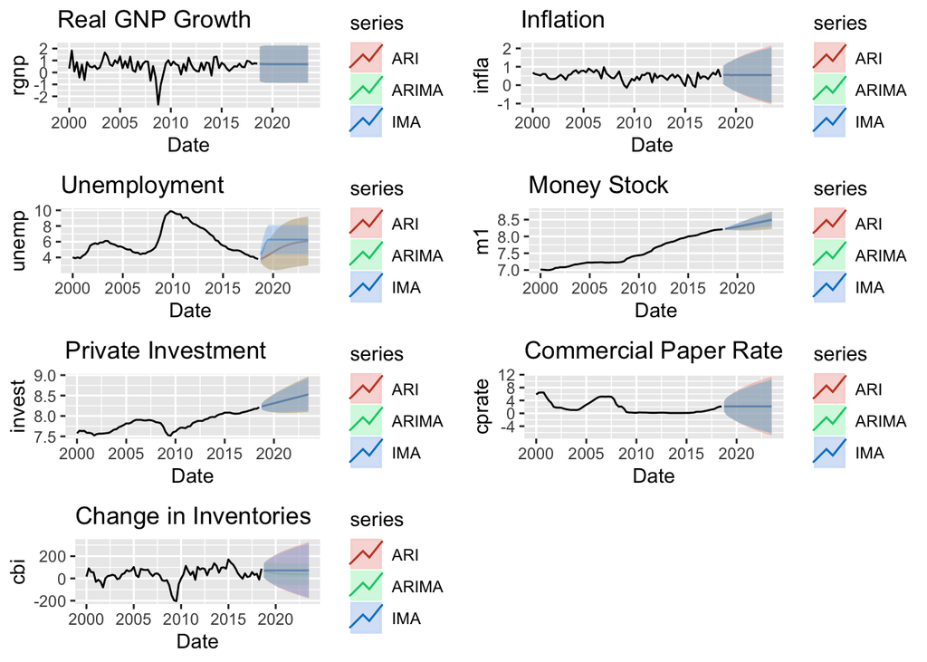

```r
#Construct Forecasts of Each Series by Univariate ARI, IMA, ARIMA models, with 95% confidence intervals
ARIfcsts<-list()
ARIMAfcsts<-list()
IMAfcsts<-list()
for (i in 1:nseries) {
  ARIfcsts[[i]]<-forecast::forecast(ARIstatmodels[[i]],h=20,level=95)
  ARIMAfcsts[[i]]<-forecast::forecast(ARIMAstatmodels[[i]],h=20,level=95)
  IMAfcsts[[i]]<-forecast::forecast(IMAstatmodels[[i]],h=20,level=95)
}

forecastplots<-list()
for (i in 1:nseries){
pastwindow<-window(macrodata[,i],start=c(2000,1))
#Plot all forecasts
forecastplots[[i]]<-autoplot(pastwindow)+
  autolayer(ARIMAfcsts[[i]],alpha=0.4,series="ARIMA")+
  autolayer(ARIfcsts[[i]],alpha=0.4,series="ARI")+
  autolayer(IMAfcsts[[i]],alpha=0.4,series="IMA")+
  labs(x="Date",y=colnames(macrodata)[i],title=Series[i])
}

grid.arrange(grobs=forecastplots,nrow=4,ncol=2)
```

## The Multivariate Case

- Vector Autoregression (VAR), Vector Moving Average (VMA), and Vector ARMA (VARMA) models similar to 1 variable case, but with more coefficients
- Vector Autoregression much more commonly used than VMA or VARMA cases, so discuss only this
  - By equivalence relationships, can represent all as infinite order VAR
- With $m$ variables, $y_t=(y_{1,t},\ldots,y_{m,t})\in\mathbb{R}^m$
- For all $t=p+1\ldots T$, $i=1\ldots m$, the VAR(p) model is $y_{i,t}=b_{i,0}+\sum_{k=1}^{m}\sum_{j=1}^{p}b_{i,jk}y_{k,t-j}+\epsilon_{k,t}$
- Where for all t, k, j, $h\neq0$, $E[\epsilon_{k,t}]=0$, $E[\epsilon_{k,t}\epsilon_{j,t+h}]=0$
- Collecting coefficients in matrices, can write as $y_t=B_0+\sum_{j=1}^{p}B_jy_{t-j}+\epsilon_t$
- Typical to assume $\epsilon_t\overset{iid}{\sim} N(0,\Sigma_\epsilon)$, where $\Sigma_\epsilon\in\mathbb{R}^{m\times m}$ gives present covariance
- (log) Likelihood again takes (multivariate) normal form: weighted least squares
- Stationarity conditions analogous to m=1 case: roots (of particular polynomial) inside unit circle
  - `roots` in library `vars` can display

## Multivariate VAR Priors

- Can construct multivariate version of normal-gamma priors for VARs which is also conjugate
- Multivariate normal $N(\mu_B,\Sigma_B)$ prior on $B_j$, $j=1\ldots p$ with covariances $\Sigma_B$
  - With $m$ variables, $p$ lags, have $m(p+1)$ coefficients, so $(mp+m)^2$ prior parameters to choose just here
- **Inverse Wishart** distribution $W(\Psi,\nu)$ on $\Sigma_\epsilon$ multivariate version of Gamma distribution
  - $\Psi\in\mathcal{R}^{m\times m}$ is prior guess of $\Sigma_\epsilon$, $\nu\in\mathbb{R}$ sets concentration
- Minnesota priors due to Doan, Litterman, Sims (1984), at FRB Minneapolis can help simplify choices
- Goal is to express typical properties of macroeconomic series for business cycle forecasting
- Prior mean for $b_{i,1i}=1$, all other coefs 0 (equivalently, $B_1=I_m$ identity matrix)
  - Each series centered on random walk in just itself, with lags and cross-equation effects 0
- Variances $\sigma^2_{\epsilon,i}$ $i=1\ldots m$ in $\Sigma_\epsilon$ estimated by sample variance of residuals from 1 dimensional AR(p)
- All prior covariances across coefficients set to 0: independent normal guesses for each
  - Variances are $\Sigma_{b_{i,jk}}=$ $H_1/h(j)$ for own lags $H_2\sigma^2_{\epsilon,i}/(h(j)\sigma^2_{\epsilon,k})$ for $i,jk$ coefficient, $H_3\sigma^2_{\epsilon,i}$ for constant
  - Parameters $H_1,H_2,H_3$ set tightness of prior around own lags, cross-variable effects, and constants, respectively

## Application: Litterman (1986) Macroeconomic Forecasts

- Minnesota priors developed for macro forecasting applications at the Federal Reserve
  - Alternative to large, complicated and somewhat untrustworthy explicit economic models used at the time
  - Allows many variables to enter in unrestricted way, but minimizes oerfitting due to priors
- Litterman went on to be chief economist at Goldman Sachs, and method spread to private sector
- Example from Litterman (1986): BVAR with Minnesota priors over 7 variables from before
- 6 lags in each variable, with a constant
- Choose prior parameters $H_1=1$, $H_2=0.2$, $H_3=1$, $h(j)=j^{-2}$
  - Noting that scale is proportional to variance estimates, says expect constant to deviate by 1 standard deviation of series
  - Own first lag deviates from 1 by about standard deviation of series, later lags have variance decaying harmonically
  - Cross-equation effects expected to vary 20% as much as own-lag effects from 0
- Implement using `bvarm` function in [BMR library](https://www.kthohr.com/bmr.html) for Bayesian VARs and related models used in macroeconomics
- Forecasts and corresponding intervals appear reasonable despite that some series (M1, Investment) are clearly trending

## Forecasts from ARIMA (Red) and BVAR (Blue)

```r
#Convert to a data frame
bvarmacrodata <- data.matrix(macrodata)

#Set up Minnesota-prior BVAR object, and sample from posterior by MCMC
# See https://www.kthohr.com/bmr_docs_vars_bvarm.html for syntax documentation: manual is out of date
bvar_obj <- new(bvarm)

#Construct BVAR with nlags lags and a constant
bvar_obj$build(data_endog=bvarmacrodata,cons_term=TRUE,p=nlags)

#Set random walk prior mean for all variables
coef_prior=c(1,1,1,1,1,1,1)
# Set prior parameters (1,0.2,1) with harmonic decay
bvar_obj$prior(coef_prior=coef_prior,var_type=1,decay_type=1,HP_1=1,HP_2=0.2,HP_3=1,HP_4=2)

#Sample from BVAR with 10000 draws of Gibbs Sampler
bvar_obj$gibbs(10000)

#Construct BVAR Forecasts
bvarfcst<-forecast(bvar_obj,periods=20,shocks=TRUE,plot=FALSE,varnames=colnames(macrodata),percentiles=c(.05,.50,.95),
    use_mean=FALSE,back_data=0,save=FALSE,height=13,width=11)

#Warning: command is incredibly slow if plot=TRUE is on, fast otherwise
# Appears to be issue with plotting code in BMR package, which slows down plotting to visualize
# With too many lags and series, have to wait through hundreds of forced pauses
```

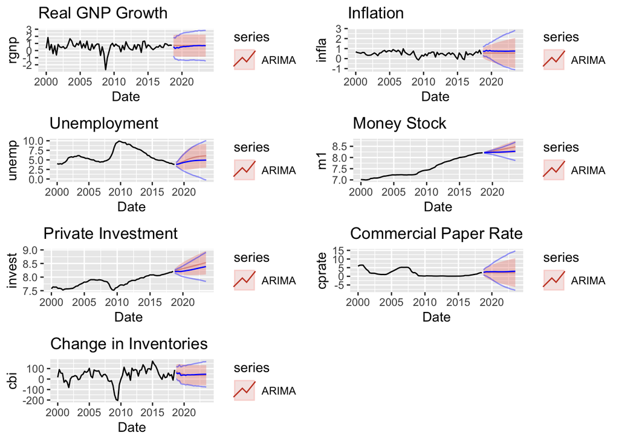

```r
# ADD VAR and ARIMA forecasts to plot

forecastseriesplots<-list()
for (i in 1:nseries){
BVAR<-ts(bvarfcst$forecast_mean[,i],start=c(2018,4),frequency=4,names=Series[i]) #Mean
lcband<-ts(bvarfcst$plot_vals[,1,i],start=c(2018,4),frequency=4,names=Series[i]) #5% Lower confidence band
ucband<-ts(bvarfcst$plot_vals[,3,i],start=c(2018,4),frequency=4,names=Series[i]) #95% Upper confidence band
fdate<-time(lcband) #Extract date so geom_ribbon() knows what x value is
bands<-data.frame(fdate,lcband,ucband) #Collect in data frame
pastwindow<-window(macrodata[,i],start=c(2000,1))
#Plot ARIMA model forecast along with BVAR forecasts, plus respective 95% intervals
forecastseriesplots[[i]]<-autoplot(pastwindow)+
  autolayer(ARIMAfcsts[[i]],series="ARIMA",alpha=0.4)+
  autolayer(BVAR,series="BVAR",color="blue")+
  geom_line(aes(x=fdate,y=ucband),data=bands,color="blue",alpha=0.4)+
  geom_line(aes(x=fdate,y=lcband),data=bands,color="blue",alpha=0.4)+
  labs(x="Date",y=colnames(macrodata)[i],title=Series[i])
}

grid.arrange(grobs=forecastseriesplots,nrow=4,ncol=2)
```

## Interpretation

- Point forecasts differ somewhat, but within respective uncertainty intervals
  - Note: Bayesian predictive intervals are not confidence intervals and vice versa
  - Predictive intervals give best average-case prediction of distribution given data over the model
  - Confidence intervals construct region containing data 95% of the time, if model specification true
- BVAR uses longer lags, prior centered at unit root to account for persistent dynamics
  - Order of AR lags must be longer both to account for integration and for possibility of MA dynamics
  - Prior over higher lags reduces variability of estimates, reduces overfitting by regularization
- Test-based approach attempts to detect unit roots and difference them out, then find best stationary ARMA model
  - Model selection by AICc acts against overfitting, but leaves remaining coefficients unrestricted

## Conclusions

- Latent variable models like moving averages can be used to concisely describe data features
  - Since not seen, representations are not unique
  - AR and MA equivalent, but one may be much more efficient, taking finite rather than infinite order
- Latent models can be combined with models of observables like autoregressions (with or without integration) to extend descriptive capability
- Multivariate case results in many more parameters, especially if using high order VAR
  - But Bayesian approach allows imposing discipline using priors

## References

- Thomas Doan, Robert Litterman & Christopher Sims “Forecasting and conditional projection using realistic prior distributions” Econometric Reviews Vol 3. No 1 (1984)
  - Introduced the Minnesota prior
- Robert B. Litterman, “Forecasting with Bayesian Vector Autoregressions: Five Years of Experience” Journal of Business & Economic Statistics, Vol. 4, No. 1 (Jan., 1986), pp. 25-38
- Joe Mahon & Phil Davies “The Meaning of Slutsky” *The Region* December 2009 (https://www.minneapolisfed.org/publications/the-region/the-meaning-of-slutsky)
  - History of Eugen Slutsky and the “shocks” approach to modeling economic data
- Keith O’Hara, “Bayesian Macroeconometrics in R” (2015) (https://www.kthohr.com/bmr.html)
  - Library for Bayesian VARs and related models